# Risk Factor Analysis

## Outcome Variable

**Outcome Variable:** wasted

## Predictor Variables

**Intervention Variable:** mbmi

**Adjustment Set:**

- arm
- W_mage
- W_fage
- meducyrs
- feducyrs
- single
- brthmon
- delta_W_mage
- delta_W_fage
- delta_meducyrs
- delta_feducyrs
- delta_single
- delta_brthmon

## Stratifying Variables

The analysis was stratified on these variable(s):

- agecat
- studyid
- country

## Data Summary

| agecat | studyid | country | mbmi | wasted | n_cell | n |
| --- | --- | --- | --- | --- | --- | --- |
| Birth | ki0047075b-MAL-ED | BANGLADESH | Normal weight | 0 | 173 | 233 |
| Birth | ki0047075b-MAL-ED | BANGLADESH | Normal weight | 1 | 32 | 233 |
| Birth | ki0047075b-MAL-ED | BANGLADESH | Underweight | 0 | 21 | 233 |
| Birth | ki0047075b-MAL-ED | BANGLADESH | Underweight | 1 | 7 | 233 |
| Birth | ki0047075b-MAL-ED | BRAZIL | Normal weight | 0 | 162 | 176 |
| Birth | ki0047075b-MAL-ED | BRAZIL | Normal weight | 1 | 5 | 176 |
| Birth | ki0047075b-MAL-ED | BRAZIL | Underweight | 0 | 8 | 176 |
| Birth | ki0047075b-MAL-ED | BRAZIL | Underweight | 1 | 1 | 176 |
| Birth | ki0047075b-MAL-ED | INDIA | Normal weight | 0 | 134 | 195 |
| Birth | ki0047075b-MAL-ED | INDIA | Normal weight | 1 | 23 | 195 |
| Birth | ki0047075b-MAL-ED | INDIA | Underweight | 0 | 29 | 195 |
| Birth | ki0047075b-MAL-ED | INDIA | Underweight | 1 | 9 | 195 |
| Birth | ki0047075b-MAL-ED | NEPAL | Normal weight | 0 | 147 | 167 |
| Birth | ki0047075b-MAL-ED | NEPAL | Normal weight | 1 | 20 | 167 |
| Birth | ki0047075b-MAL-ED | NEPAL | Underweight | 0 | 0 | 167 |
| Birth | ki0047075b-MAL-ED | NEPAL | Underweight | 1 | 0 | 167 |
| Birth | ki0047075b-MAL-ED | PERU | Normal weight | 0 | 258 | 269 |
| Birth | ki0047075b-MAL-ED | PERU | Normal weight | 1 | 6 | 269 |
| Birth | ki0047075b-MAL-ED | PERU | Underweight | 0 | 5 | 269 |
| Birth | ki0047075b-MAL-ED | PERU | Underweight | 1 | 0 | 269 |
| Birth | ki0047075b-MAL-ED | SOUTH AFRICA | Normal weight | 0 | 208 | 226 |
| Birth | ki0047075b-MAL-ED | SOUTH AFRICA | Normal weight | 1 | 13 | 226 |
| Birth | ki0047075b-MAL-ED | SOUTH AFRICA | Underweight | 0 | 5 | 226 |
| Birth | ki0047075b-MAL-ED | SOUTH AFRICA | Underweight | 1 | 0 | 226 |
| Birth | ki0047075b-MAL-ED | TANZANIA, UNITED REPUBLIC OF | Normal weight | 0 | 107 | 116 |
| Birth | ki0047075b-MAL-ED | TANZANIA, UNITED REPUBLIC OF | Normal weight | 1 | 2 | 116 |
| Birth | ki0047075b-MAL-ED | TANZANIA, UNITED REPUBLIC OF | Underweight | 0 | 7 | 116 |
| Birth | ki0047075b-MAL-ED | TANZANIA, UNITED REPUBLIC OF | Underweight | 1 | 0 | 116 |
| Birth | ki1000304b-SAS-CompFeed | INDIA | Normal weight | 0 | 73 | 110 |
| Birth | ki1000304b-SAS-CompFeed | INDIA | Normal weight | 1 | 4 | 110 |

[output cut: 134 more lines]

The following strata were considered:

- agecat: 24 months, studyid: ki0047075b-MAL-ED, country: BANGLADESH
- agecat: 24 months, studyid: ki0047075b-MAL-ED, country: BRAZIL
- agecat: 24 months, studyid: ki0047075b-MAL-ED, country: INDIA
- agecat: 24 months, studyid: ki0047075b-MAL-ED, country: NEPAL
- agecat: 24 months, studyid: ki0047075b-MAL-ED, country: PERU
- agecat: 24 months, studyid: ki0047075b-MAL-ED, country: SOUTH AFRICA
- agecat: 24 months, studyid: ki0047075b-MAL-ED, country: TANZANIA, UNITED REPUBLIC OF
- agecat: 24 months, studyid: ki1017093-NIH-Birth, country: BANGLADESH
- agecat: 24 months, studyid: ki1017093b-PROVIDE, country: BANGLADESH
- agecat: 24 months, studyid: ki1017093c-NIH-Crypto, country: BANGLADESH
- agecat: 24 months, studyid: ki1066203-TanzaniaChild2, country: TANZANIA, UNITED REPUBLIC OF
- agecat: 24 months, studyid: ki1119695-PROBIT, country: BELARUS
- agecat: 24 months, studyid: ki1126311-ZVITAMBO, country: ZIMBABWE
- agecat: 24 months, studyid: ki1148112-LCNI-5, country: MALAWI
- agecat: 6 months, studyid: ki0047075b-MAL-ED, country: BANGLADESH
- agecat: 6 months, studyid: ki0047075b-MAL-ED, country: BRAZIL
- agecat: 6 months, studyid: ki0047075b-MAL-ED, country: INDIA
- agecat: 6 months, studyid: ki0047075b-MAL-ED, country: NEPAL
- agecat: 6 months, studyid: ki0047075b-MAL-ED, country: PERU
- agecat: 6 months, studyid: ki0047075b-MAL-ED, country: SOUTH AFRICA
- agecat: 6 months, studyid: ki0047075b-MAL-ED, country: TANZANIA, UNITED REPUBLIC OF
- agecat: 6 months, studyid: ki1000304b-SAS-CompFeed, country: INDIA
- agecat: 6 months, studyid: ki1017093-NIH-Birth, country: BANGLADESH
- agecat: 6 months, studyid: ki1017093b-PROVIDE, country: BANGLADESH
- agecat: 6 months, studyid: ki1017093c-NIH-Crypto, country: BANGLADESH
- agecat: 6 months, studyid: ki1066203-TanzaniaChild2, country: TANZANIA, UNITED REPUBLIC OF
- agecat: 6 months, studyid: ki1119695-PROBIT, country: BELARUS
- agecat: 6 months, studyid: ki1126311-ZVITAMBO, country: ZIMBABWE
- agecat: 6 months, studyid: ki1148112-LCNI-5, country: MALAWI
- agecat: Birth, studyid: ki0047075b-MAL-ED, country: BANGLADESH
- agecat: Birth, studyid: ki0047075b-MAL-ED, country: BRAZIL
- agecat: Birth, studyid: ki0047075b-MAL-ED, country: INDIA
- agecat: Birth, studyid: ki0047075b-MAL-ED, country: NEPAL
- agecat: Birth, studyid: ki0047075b-MAL-ED, country: PERU
- agecat: Birth, studyid: ki0047075b-MAL-ED, country: SOUTH AFRICA
- agecat: Birth, studyid: ki0047075b-MAL-ED, country: TANZANIA, UNITED REPUBLIC OF
- agecat: Birth, studyid: ki1000304b-SAS-CompFeed, country: INDIA
- agecat: Birth, studyid: ki1017093-NIH-Birth, country: BANGLADESH
- agecat: Birth, studyid: ki1017093c-NIH-Crypto, country: BANGLADESH
- agecat: Birth, studyid: ki1119695-PROBIT, country: BELARUS
- agecat: Birth, studyid: ki1126311-ZVITAMBO, country: ZIMBABWE

### Dropped Strata

Some strata were dropped due to rare outcomes:

- agecat: Birth, studyid: ki0047075b-MAL-ED, country: BRAZIL
- agecat: Birth, studyid: ki0047075b-MAL-ED, country: NEPAL
- agecat: Birth, studyid: ki0047075b-MAL-ED, country: PERU
- agecat: Birth, studyid: ki0047075b-MAL-ED, country: SOUTH AFRICA
- agecat: Birth, studyid: ki0047075b-MAL-ED, country: TANZANIA, UNITED REPUBLIC OF
- agecat: Birth, studyid: ki1000304b-SAS-CompFeed, country: INDIA
- agecat: Birth, studyid: ki1017093-NIH-Birth, country: BANGLADESH
- agecat: Birth, studyid: ki1017093c-NIH-Crypto, country: BANGLADESH
- agecat: 6 months, studyid: ki0047075b-MAL-ED, country: BANGLADESH
- agecat: 6 months, studyid: ki0047075b-MAL-ED, country: BRAZIL
- agecat: 6 months, studyid: ki0047075b-MAL-ED, country: NEPAL
- agecat: 6 months, studyid: ki0047075b-MAL-ED, country: PERU
- agecat: 6 months, studyid: ki0047075b-MAL-ED, country: SOUTH AFRICA
- agecat: 6 months, studyid: ki0047075b-MAL-ED, country: TANZANIA, UNITED REPUBLIC OF
- agecat: 6 months, studyid: ki1066203-TanzaniaChild2, country: TANZANIA, UNITED REPUBLIC OF
- agecat: 6 months, studyid: ki1148112-LCNI-5, country: MALAWI
- agecat: 24 months, studyid: ki0047075b-MAL-ED, country: BRAZIL
- agecat: 24 months, studyid: ki0047075b-MAL-ED, country: NEPAL
- agecat: 24 months, studyid: ki0047075b-MAL-ED, country: PERU
- agecat: 24 months, studyid: ki0047075b-MAL-ED, country: SOUTH AFRICA
- agecat: 24 months, studyid: ki0047075b-MAL-ED, country: TANZANIA, UNITED REPUBLIC OF
- agecat: 24 months, studyid: ki1017093c-NIH-Crypto, country: BANGLADESH
- agecat: 24 months, studyid: ki1066203-TanzaniaChild2, country: TANZANIA, UNITED REPUBLIC OF

## Methods Detail

We’re interested in the causal parameters $E[Y_a]$ for all values of $a \in \mathcal{A}$. These parameters represent the mean outcome if, possibly contrary to fact, we intervened to set all units to have $A=a$. Under the randomization and positivity assumptions, these are identified by the statistical parameters $\psi_a=E_W[E_{Y|A,W}(Y|A=a,W)]$. In addition, we’re interested in the mean of $Y$, $E[Y]$ under no intervention (the observed mean). We will estimate these parameters by using SuperLearner to fit the relevant likelihood factors – $E_{Y|A,W}(Y|A=a,W)$ and $p(A=a|W)$, and then updating our likelihood fit using a joint TMLE.

For unadjusted analyses ($W=\{\}$), initial likelihoods were estimated using Lrnr_glm to estimate the simple $E(Y|A)$ and Lrnr_mean to estimate $p(A)$. For adjusted analyses, a small library containing Lrnr_glmnet, Lrnr_xgboost, and Lrnr_mean was used.

Having estimated these parameters, we will then use the delta method to estimate relative risks and attributable risks relative to a prespecified baseline level of $A$.

# Results Detail

## Results Plots

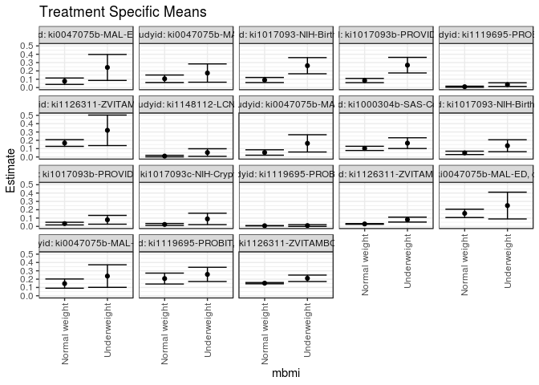

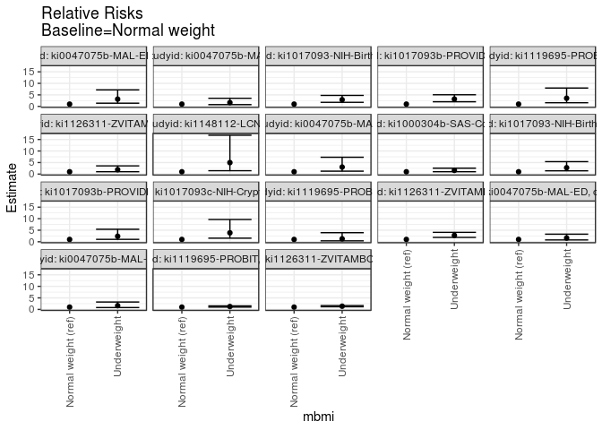

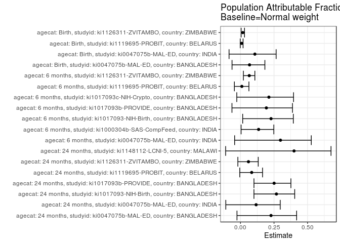

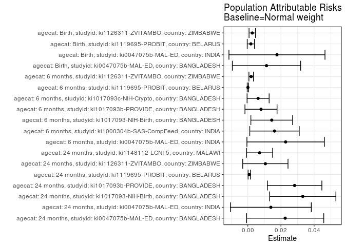

## Results Table

### Parameter: TSM

| agecat | studyid | country | intervention_level | baseline_level | estimate | ci_lower | ci_upper |
| --- | --- | --- | --- | --- | --- | --- | --- |
| Birth | ki0047075b-MAL-ED | BANGLADESH | Normal weight | NA | 0.1560976 | 0.1063067 | 0.2058884 |
| Birth | ki0047075b-MAL-ED | BANGLADESH | Underweight | NA | 0.2500000 | 0.0892675 | 0.4107325 |
| Birth | ki0047075b-MAL-ED | INDIA | Normal weight | NA | 0.1464968 | 0.0910430 | 0.2019506 |
| Birth | ki0047075b-MAL-ED | INDIA | Underweight | NA | 0.2368421 | 0.1013202 | 0.3723640 |
| Birth | ki1119695-PROBIT | BELARUS | Normal weight | NA | 0.2069441 | 0.1416249 | 0.2722633 |
| Birth | ki1119695-PROBIT | BELARUS | Underweight | NA | 0.2568756 | 0.1714393 | 0.3423119 |
| Birth | ki1126311-ZVITAMBO | ZIMBABWE | Normal weight | NA | 0.1515706 | 0.1439713 | 0.1591698 |
| Birth | ki1126311-ZVITAMBO | ZIMBABWE | Underweight | NA | 0.2101283 | 0.1715357 | 0.2487210 |
| 6 months | ki0047075b-MAL-ED | INDIA | Normal weight | NA | 0.0537634 | 0.0212801 | 0.0862468 |
| 6 months | ki0047075b-MAL-ED | INDIA | Underweight | NA | 0.1632653 | 0.0595562 | 0.2669744 |
| 6 months | ki1000304b-SAS-CompFeed | INDIA | Normal weight | NA | 0.1030664 | 0.0776193 | 0.1285134 |
| 6 months | ki1000304b-SAS-CompFeed | INDIA | Underweight | NA | 0.1659045 | 0.1014237 | 0.2303853 |
| 6 months | ki1017093-NIH-Birth | BANGLADESH | Normal weight | NA | 0.0489800 | 0.0287734 | 0.0691867 |
| 6 months | ki1017093-NIH-Birth | BANGLADESH | Underweight | NA | 0.1351645 | 0.0635847 | 0.2067444 |
| 6 months | ki1017093b-PROVIDE | BANGLADESH | Normal weight | NA | 0.0333333 | 0.0172610 | 0.0494057 |
| 6 months | ki1017093b-PROVIDE | BANGLADESH | Underweight | NA | 0.0792079 | 0.0264938 | 0.1319220 |
| 6 months | ki1017093c-NIH-Crypto | BANGLADESH | Normal weight | NA | 0.0231481 | 0.0115621 | 0.0347342 |
| 6 months | ki1017093c-NIH-Crypto | BANGLADESH | Underweight | NA | 0.0895522 | 0.0211327 | 0.1579718 |
| 6 months | ki1119695-PROBIT | BELARUS | Normal weight | NA | 0.0078281 | 0.0057317 | 0.0099246 |
| 6 months | ki1119695-PROBIT | BELARUS | Underweight | NA | 0.0099010 | -0.0006297 | 0.0204317 |
| 6 months | ki1126311-ZVITAMBO | ZIMBABWE | Normal weight | NA | 0.0294091 | 0.0253675 | 0.0334507 |
| 6 months | ki1126311-ZVITAMBO | ZIMBABWE | Underweight | NA | 0.0812456 | 0.0517359 | 0.1107552 |
| 24 months | ki0047075b-MAL-ED | BANGLADESH | Normal weight | NA | 0.0765027 | 0.0379011 | 0.1151044 |
| 24 months | ki0047075b-MAL-ED | BANGLADESH | Underweight | NA | 0.2413793 | 0.0852666 | 0.3974920 |
| 24 months | ki0047075b-MAL-ED | INDIA | Normal weight | NA | 0.1055556 | 0.0605680 | 0.1505431 |
| 24 months | ki0047075b-MAL-ED | INDIA | Underweight | NA | 0.1739130 | 0.0641361 | 0.2836900 |
| 24 months | ki1017093-NIH-Birth | BANGLADESH | Normal weight | NA | 0.0906527 | 0.0602330 | 0.1210723 |
| 24 months | ki1017093-NIH-Birth | BANGLADESH | Underweight | NA | 0.2626741 | 0.1658010 | 0.3595472 |
| 24 months | ki1017093b-PROVIDE | BANGLADESH | Normal weight | NA | 0.0843998 | 0.0590918 | 0.1097078 |
| 24 months | ki1017093b-PROVIDE | BANGLADESH | Underweight | NA | 0.2687728 | 0.1751268 | 0.3624187 |
| 24 months | ki1119695-PROBIT | BELARUS | Normal weight | NA | 0.0100000 | 0.0031380 | 0.0168620 |
| 24 months | ki1119695-PROBIT | BELARUS | Underweight | NA | 0.0354610 | 0.0131895 | 0.0577325 |
| 24 months | ki1126311-ZVITAMBO | ZIMBABWE | Normal weight | NA | 0.1676647 | 0.1275456 | 0.2077837 |
| 24 months | ki1126311-ZVITAMBO | ZIMBABWE | Underweight | NA | 0.3200000 | 0.1368895 | 0.5031105 |
| 24 months | ki1148112-LCNI-5 | MALAWI | Normal weight | NA | 0.0107066 | 0.0013641 | 0.0200492 |
| 24 months | ki1148112-LCNI-5 | MALAWI | Underweight | NA | 0.0531915 | 0.0077844 | 0.0985986 |

### Parameter: E(Y)

| agecat | studyid | country | intervention_level | baseline_level | estimate | ci_lower | ci_upper |
| --- | --- | --- | --- | --- | --- | --- | --- |
| Birth | ki0047075b-MAL-ED | BANGLADESH | NA | NA | 0.1673820 | 0.1193444 | 0.2154196 |
| Birth | ki0047075b-MAL-ED | INDIA | NA | NA | 0.1641026 | 0.1119853 | 0.2162198 |
| Birth | ki1119695-PROBIT | BELARUS | NA | NA | 0.2087968 | 0.1432289 | 0.2743648 |
| Birth | ki1126311-ZVITAMBO | ZIMBABWE | NA | NA | 0.1542807 | 0.1468295 | 0.1617318 |
| 6 months | ki0047075b-MAL-ED | INDIA | NA | NA | 0.0765957 | 0.0425205 | 0.1106709 |
| 6 months | ki1000304b-SAS-CompFeed | INDIA | NA | NA | 0.1191837 | 0.0947144 | 0.1436529 |
| 6 months | ki1017093-NIH-Birth | BANGLADESH | NA | NA | 0.0634328 | 0.0427791 | 0.0840865 |
| 6 months | ki1017093b-PROVIDE | BANGLADESH | NA | NA | 0.0413081 | 0.0251127 | 0.0575035 |
| 6 months | ki1017093c-NIH-Crypto | BANGLADESH | NA | NA | 0.0293706 | 0.0169860 | 0.0417552 |
| 6 months | ki1119695-PROBIT | BELARUS | NA | NA | 0.0079085 | 0.0059160 | 0.0099010 |
| 6 months | ki1126311-ZVITAMBO | ZIMBABWE | NA | NA | 0.0314661 | 0.0274014 | 0.0355307 |
| 24 months | ki0047075b-MAL-ED | BANGLADESH | NA | NA | 0.0990566 | 0.0587480 | 0.1393652 |
| 24 months | ki0047075b-MAL-ED | INDIA | NA | NA | 0.1194690 | 0.0770894 | 0.1618486 |
| 24 months | ki1017093-NIH-Birth | BANGLADESH | NA | NA | 0.1238318 | 0.0925894 | 0.1550741 |
| 24 months | ki1017093b-PROVIDE | BANGLADESH | NA | NA | 0.1126516 | 0.0868319 | 0.1384714 |
| 24 months | ki1119695-PROBIT | BELARUS | NA | NA | 0.0109109 | 0.0040853 | 0.0177366 |
| 24 months | ki1126311-ZVITAMBO | ZIMBABWE | NA | NA | 0.1782730 | 0.1386257 | 0.2179202 |
| 24 months | ki1148112-LCNI-5 | MALAWI | NA | NA | 0.0178253 | 0.0068664 | 0.0287842 |

### Parameter: RR

| agecat | studyid | country | intervention_level | baseline_level | estimate | ci_lower | ci_upper |
| --- | --- | --- | --- | --- | --- | --- | --- |
| Birth | ki0047075b-MAL-ED | BANGLADESH | Normal weight | Normal weight | 1.000000 | 1.0000000 | 1.000000 |
| Birth | ki0047075b-MAL-ED | BANGLADESH | Underweight | Normal weight | 1.601562 | 0.7813543 | 3.282765 |
| Birth | ki0047075b-MAL-ED | INDIA | Normal weight | Normal weight | 1.000000 | 1.0000000 | 1.000000 |
| Birth | ki0047075b-MAL-ED | INDIA | Underweight | Normal weight | 1.616705 | 0.8140867 | 3.210634 |
| Birth | ki1119695-PROBIT | BELARUS | Normal weight | Normal weight | 1.000000 | 1.0000000 | 1.000000 |
| Birth | ki1119695-PROBIT | BELARUS | Underweight | Normal weight | 1.241280 | 0.9993731 | 1.541742 |
| Birth | ki1126311-ZVITAMBO | ZIMBABWE | Normal weight | Normal weight | 1.000000 | 1.0000000 | 1.000000 |
| Birth | ki1126311-ZVITAMBO | ZIMBABWE | Underweight | Normal weight | 1.386340 | 1.1459979 | 1.677088 |
| 6 months | ki0047075b-MAL-ED | INDIA | Normal weight | Normal weight | 1.000000 | 1.0000000 | 1.000000 |
| 6 months | ki0047075b-MAL-ED | INDIA | Underweight | Normal weight | 3.036735 | 1.2637883 | 7.296916 |
| 6 months | ki1000304b-SAS-CompFeed | INDIA | Normal weight | Normal weight | 1.000000 | 1.0000000 | 1.000000 |
| 6 months | ki1000304b-SAS-CompFeed | INDIA | Underweight | Normal weight | 1.609686 | 1.0115484 | 2.561509 |
| 6 months | ki1017093-NIH-Birth | BANGLADESH | Normal weight | Normal weight | 1.000000 | 1.0000000 | 1.000000 |
| 6 months | ki1017093-NIH-Birth | BANGLADESH | Underweight | Normal weight | 2.759584 | 1.4097662 | 5.401819 |
| 6 months | ki1017093b-PROVIDE | BANGLADESH | Normal weight | Normal weight | 1.000000 | 1.0000000 | 1.000000 |
| 6 months | ki1017093b-PROVIDE | BANGLADESH | Underweight | Normal weight | 2.376238 | 1.0446605 | 5.405110 |
| 6 months | ki1017093c-NIH-Crypto | BANGLADESH | Normal weight | Normal weight | 1.000000 | 1.0000000 | 1.000000 |
| 6 months | ki1017093c-NIH-Crypto | BANGLADESH | Underweight | Normal weight | 3.868657 | 1.5519898 | 9.643430 |
| 6 months | ki1119695-PROBIT | BELARUS | Normal weight | Normal weight | 1.000000 | 1.0000000 | 1.000000 |
| 6 months | ki1119695-PROBIT | BELARUS | Underweight | Normal weight | 1.264801 | 0.4065976 | 3.934409 |
| 6 months | ki1126311-ZVITAMBO | ZIMBABWE | Normal weight | Normal weight | 1.000000 | 1.0000000 | 1.000000 |
| 6 months | ki1126311-ZVITAMBO | ZIMBABWE | Underweight | Normal weight | 2.762598 | 1.8735529 | 4.073517 |
| 24 months | ki0047075b-MAL-ED | BANGLADESH | Normal weight | Normal weight | 1.000000 | 1.0000000 | 1.000000 |
| 24 months | ki0047075b-MAL-ED | BANGLADESH | Underweight | Normal weight | 3.155172 | 1.3892244 | 7.165950 |
| 24 months | ki0047075b-MAL-ED | INDIA | Normal weight | Normal weight | 1.000000 | 1.0000000 | 1.000000 |
| 24 months | ki0047075b-MAL-ED | INDIA | Underweight | Normal weight | 1.647597 | 0.7692713 | 3.528764 |
| 24 months | ki1017093-NIH-Birth | BANGLADESH | Normal weight | Normal weight | 1.000000 | 1.0000000 | 1.000000 |
| 24 months | ki1017093-NIH-Birth | BANGLADESH | Underweight | Normal weight | 2.897588 | 1.7599996 | 4.770466 |
| 24 months | ki1017093b-PROVIDE | BANGLADESH | Normal weight | Normal weight | 1.000000 | 1.0000000 | 1.000000 |
| 24 months | ki1017093b-PROVIDE | BANGLADESH | Underweight | Normal weight | 3.184520 | 2.0090066 | 5.047851 |
| 24 months | ki1119695-PROBIT | BELARUS | Normal weight | Normal weight | 1.000000 | 1.0000000 | 1.000000 |
| 24 months | ki1119695-PROBIT | BELARUS | Underweight | Normal weight | 3.546099 | 1.5783651 | 7.966991 |
| 24 months | ki1126311-ZVITAMBO | ZIMBABWE | Normal weight | Normal weight | 1.000000 | 1.0000000 | 1.000000 |
| 24 months | ki1126311-ZVITAMBO | ZIMBABWE | Underweight | Normal weight | 1.908571 | 1.0264640 | 3.548731 |
| 24 months | ki1148112-LCNI-5 | MALAWI | Normal weight | Normal weight | 1.000000 | 1.0000000 | 1.000000 |
| 24 months | ki1148112-LCNI-5 | MALAWI | Underweight | Normal weight | 4.968085 | 1.4656789 | 16.839889 |

### Parameter: PAR

| agecat | studyid | country | intervention_level | baseline_level | estimate | ci_lower | ci_upper |
| --- | --- | --- | --- | --- | --- | --- | --- |
| Birth | ki0047075b-MAL-ED | BANGLADESH | Normal weight | NA | 0.0112844 | -0.0093148 | 0.0318836 |
| Birth | ki0047075b-MAL-ED | INDIA | Normal weight | NA | 0.0176057 | -0.0113700 | 0.0465815 |
| Birth | ki1119695-PROBIT | BELARUS | Normal weight | NA | 0.0018527 | -0.0003497 | 0.0040551 |
| Birth | ki1126311-ZVITAMBO | ZIMBABWE | Normal weight | NA | 0.0027101 | 0.0007593 | 0.0046609 |
| 6 months | ki0047075b-MAL-ED | INDIA | Normal weight | NA | 0.0228323 | -0.0005339 | 0.0461985 |
| 6 months | ki1000304b-SAS-CompFeed | INDIA | Normal weight | NA | 0.0161173 | 0.0011912 | 0.0310434 |
| 6 months | ki1017093-NIH-Birth | BANGLADESH | Normal weight | NA | 0.0144528 | 0.0018522 | 0.0270533 |
| 6 months | ki1017093b-PROVIDE | BANGLADESH | Normal weight | NA | 0.0079748 | -0.0017094 | 0.0176589 |
| 6 months | ki1017093c-NIH-Crypto | BANGLADESH | Normal weight | NA | 0.0062225 | -0.0004333 | 0.0128782 |
| 6 months | ki1119695-PROBIT | BELARUS | Normal weight | NA | 0.0000804 | -0.0003444 | 0.0005052 |
| 6 months | ki1126311-ZVITAMBO | ZIMBABWE | Normal weight | NA | 0.0020570 | 0.0006891 | 0.0034248 |
| 24 months | ki0047075b-MAL-ED | BANGLADESH | Normal weight | NA | 0.0225539 | -0.0007348 | 0.0458425 |
| 24 months | ki0047075b-MAL-ED | INDIA | Normal weight | NA | 0.0139135 | -0.0105003 | 0.0383272 |
| 24 months | ki1017093-NIH-Birth | BANGLADESH | Normal weight | NA | 0.0331791 | 0.0131866 | 0.0531717 |
| 24 months | ki1017093b-PROVIDE | BANGLADESH | Normal weight | NA | 0.0282519 | 0.0118001 | 0.0447036 |
| 24 months | ki1119695-PROBIT | BELARUS | Normal weight | NA | 0.0009109 | 0.0001789 | 0.0016430 |
| 24 months | ki1126311-ZVITAMBO | ZIMBABWE | Normal weight | NA | 0.0106083 | -0.0030495 | 0.0242662 |
| 24 months | ki1148112-LCNI-5 | MALAWI | Normal weight | NA | 0.0071187 | -0.0007594 | 0.0149967 |

### Parameter: PAF

| agecat | studyid | country | intervention_level | baseline_level | estimate | ci_lower | ci_upper |
| --- | --- | --- | --- | --- | --- | --- | --- |
| Birth | ki0047075b-MAL-ED | BANGLADESH | Normal weight | NA | 0.0674171 | -0.0630509 | 0.1818728 |
| Birth | ki0047075b-MAL-ED | INDIA | Normal weight | NA | 0.1072850 | -0.0853434 | 0.2657255 |
| Birth | ki1119695-PROBIT | BELARUS | Normal weight | NA | 0.0088732 | -0.0017384 | 0.0193724 |
| Birth | ki1126311-ZVITAMBO | ZIMBABWE | Normal weight | NA | 0.0175660 | 0.0048575 | 0.0301123 |
| 6 months | ki0047075b-MAL-ED | INDIA | Normal weight | NA | 0.2980884 | -0.0436507 | 0.5279265 |
| 6 months | ki1000304b-SAS-CompFeed | INDIA | Normal weight | NA | 0.1352309 | 0.0046096 | 0.2487113 |
| 6 months | ki1017093-NIH-Birth | BANGLADESH | Normal weight | NA | 0.2278440 | 0.0163611 | 0.3938579 |
| 6 months | ki1017093b-PROVIDE | BANGLADESH | Normal weight | NA | 0.1930556 | -0.0635099 | 0.3877261 |
| 6 months | ki1017093c-NIH-Crypto | BANGLADESH | Normal weight | NA | 0.2118607 | -0.0276962 | 0.3955766 |
| 6 months | ki1119695-PROBIT | BELARUS | Normal weight | NA | 0.0101632 | -0.0454865 | 0.0628507 |
| 6 months | ki1126311-ZVITAMBO | ZIMBABWE | Normal weight | NA | 0.0653706 | 0.0216567 | 0.1071312 |
| 24 months | ki0047075b-MAL-ED | BANGLADESH | Normal weight | NA | 0.2276867 | -0.0260841 | 0.4186950 |
| 24 months | ki0047075b-MAL-ED | INDIA | Normal weight | NA | 0.1164609 | -0.1094308 | 0.2963587 |
| 24 months | ki1017093-NIH-Birth | BANGLADESH | Normal weight | NA | 0.2679370 | 0.1003814 | 0.4042851 |
| 24 months | ki1017093b-PROVIDE | BANGLADESH | Normal weight | NA | 0.2507896 | 0.1004770 | 0.3759845 |
| 24 months | ki1119695-PROBIT | BELARUS | Normal weight | NA | 0.0834884 | -0.0054348 | 0.1645470 |
| 24 months | ki1126311-ZVITAMBO | ZIMBABWE | Normal weight | NA | 0.0595060 | -0.0195759 | 0.1324540 |
| 24 months | ki1148112-LCNI-5 | MALAWI | Normal weight | NA | 0.3993576 | -0.1107537 | 0.6752014 |